# DS202 Final

Tessa Lanzel

2023-05-11

```r
library(tidyverse)
```

```r
library(ggplot2)
```

```r
salaries = read.csv("https://raw.githubusercontent.com/tlanzel/DS202Final/main/ds_salaries.csv")
```

github: https://github.com/tlanzel/DS202Final

# Question: Do larger companies pay more than medium or smaller companies for data science related jobs?

### Data Set

This data set includes information on salaries of data scientists and related fields from 2020 - 2023. The dataset is from Kaggle.com

This data set includes 11 different columns:  
1. work_year  
2. experience_level  
3. employment_type  
4. job_title  
5. salary  
6. salary_currency  
7. salary_in_usd  
8. employee_residence  
9. remote_ratio  
10. company_location  
11. company_size

```r
head(salaries)
```

```
##   work_year experience_level employment_type                job_title salary
## 1      2023               SE              FT Principal Data Scientist  80000
## 2      2023               MI              CT              ML Engineer  30000
## 3      2023               MI              CT              ML Engineer  25500
## 4      2023               SE              FT           Data Scientist 175000
## 5      2023               SE              FT           Data Scientist 120000
## 6      2023               SE              FT        Applied Scientist 222200
##   salary_currency salary_in_usd employee_residence remote_ratio
## 1             EUR         85847                 ES          100
## 2             USD         30000                 US          100
## 3             USD         25500                 US          100
## 4             USD        175000                 CA          100
## 5             USD        120000                 CA          100
## 6             USD        222200                 US            0
##   company_location company_size
## 1               ES            L
## 2               US            S
## 3               US            S
## 4               CA            M
## 5               CA            M
## 6               US            L
```

## Step 1: Clean the Data

```r
#get rid of any null values
salaries = salaries %>% drop_na()

#remove employment type
salaries = subset(salaries, select = -c(employment_type) )

#keep only companies located in the united states
salaries = salaries %>% filter(salaries$company_location == "US")

#remove the salary and salary_currency (only want to keep the salary in terms of usd)
salaries = subset(salaries, select = -c(salary_currency, salary))
```

## Step 2: Visual Summary

[figure not shown]

```r
#job_title variable
salaries %>% group_by(job_title) %>% count() %>% ggplot(aes(x = job_title)) + geom_bar(aes(weight = n))+labs(x = "Job Title", y = "Count", title = "Job Title")
```

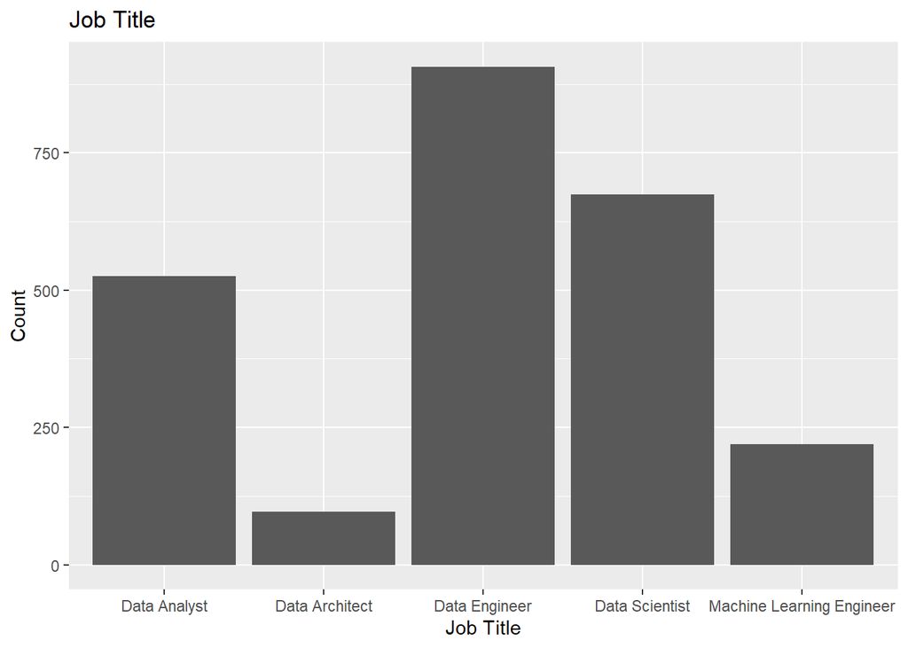

```r
salaries2 = salaries %>% group_by(job_title) %>% summarise(n = n()) %>% arrange(desc(n))

##only displays the count of the top five jobs in this data set
salaries2 = salaries2[1:5,]
salaries2 %>% ggplot(aes(x = job_title)) + geom_bar(aes(weight = n)) +labs(x = "Job Title", y = "Count", title = "Job Title")
```

This graph displays the top five jobs that have salaries reported in this dataset.It is interesting to see that there are more data engineers reported than data scientists.

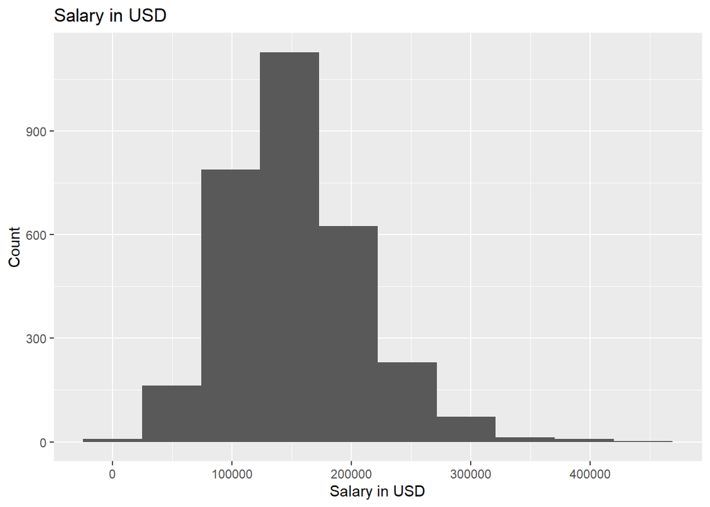

```r
#salary_in_usd variable displayed
options(scipen = 999)
salaries %>% ggplot(aes(x = salary_in_usd)) +geom_histogram(bins = 10) +labs(x = "Salary in USD", y = "Count", title = "Salary in USD")
```

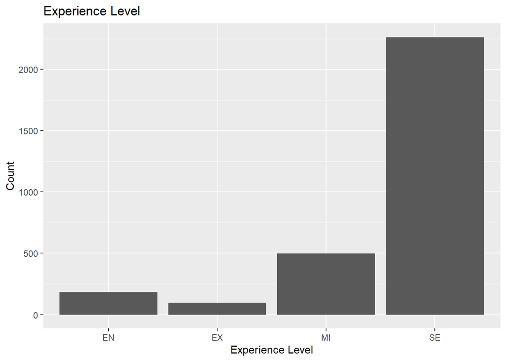

```r
#experience_level visualized
salaries %>% group_by(experience_level) %>% count() %>% ggplot(aes(x = experience_level)) + geom_bar(aes(weight = n)) +labs(x = "Experience Level", y = "Count", title = "Experience Level")
```

There are four different levels of experience: Senior Level (SE), Expert Level (EX), Mid Level (MI), and Entry Level (EN). From the graph above, the most common experience level in this data set is senior level (SE).

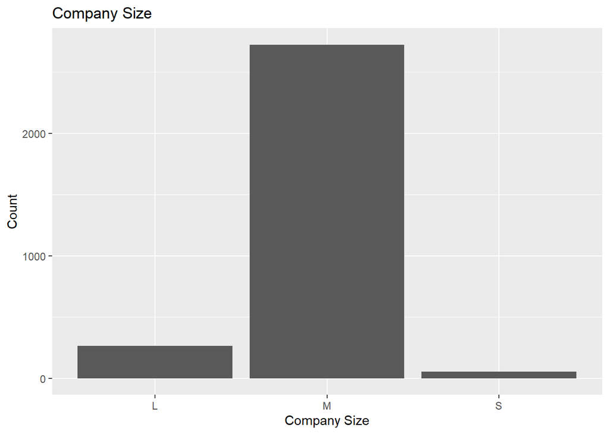

```r
salaries %>% group_by(company_size) %>% count() %>% ggplot(aes(x = company_size)) + geom_bar(aes(weight = n)) +labs(x = "Company Size", y = "Count", title = "Company Size")
```

There are three types of company in this dataset: Small (S), Medium (M), Large (L). The most common type of company in this data set is a medium sized company.

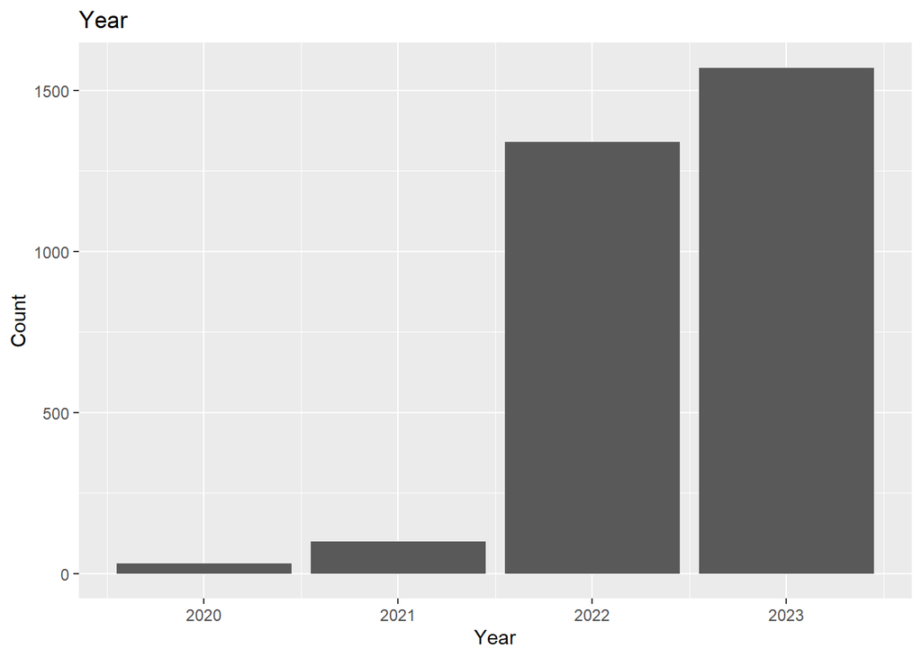

```r
#how the data is distributed by year
salaries %>% group_by(work_year) %>% count() %>% ggplot(aes(x = work_year)) + geom_bar(aes(weight = n)) +labs(x = "Year", y = "Count", title = "Year")
```

When finding this data online it was labeled as “2023 salaries for data scientists”. When looking at the data, however, I found other years included. I wanted to see the distribution of years included so I displayed the year a bar graph. I found that 2023 was the highest reported, but there are also a lot of salaries included from 2022.

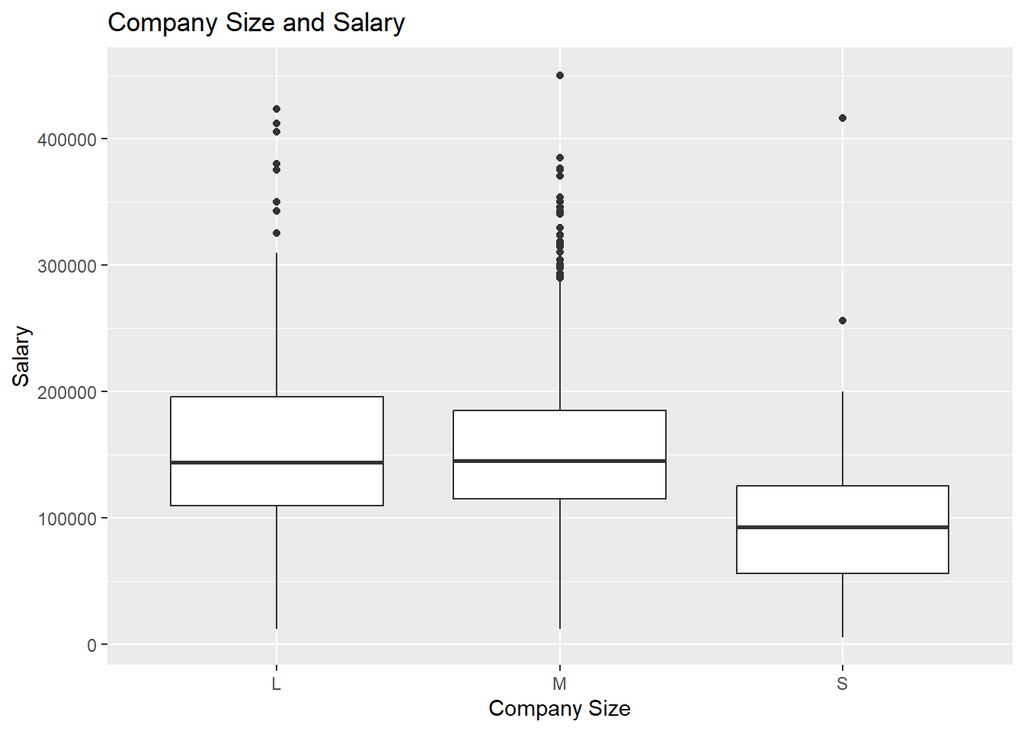

```r
salaries %>%
  ggplot(aes(x = company_size, y = salary_in_usd)) +
  geom_boxplot() +
  labs(x = "Company Size", y = "Salary", title = "Company Size and Salary")
```

After visually displaying the counts of single variables, I explored the relationship between multiple variables. The box plot above shows that the median salary is highest for medium sized companies. This was surprising because I figured it would be highest for large companies. However, large companies might have more entry level jobs compared to the other sized companies.

```r
salaries2 = salaries %>% group_by(job_title) %>% summarise(n = n()) %>% arrange(desc(n))

salaries2 = salaries2[1:5,]
salaries2
```

```
## # A tibble: 5 × 2
##   job_title                     n
##   <chr>                     <int>
## 1 Data Engineer               907
## 2 Data Scientist              674
## 3 Data Analyst                525
## 4 Machine Learning Engineer   219
## 5 Data Architect               97
```

```r
salaries4 = salaries %>% filter(salaries$job_title == "Data Engineer" |
                                salaries$job_title == "Data Scientist" |
                                  salaries$job_title == "Data Analyst" |
                     salaries$job_title == "Machine Learning Engineer" |
                            salaries$job_title == "Analytics Engineer")
```

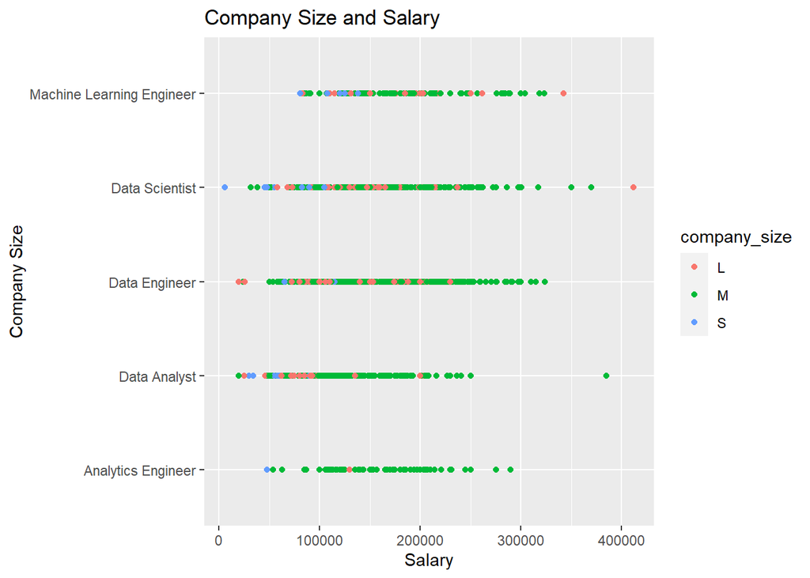

```r
salaries4 %>%
  ggplot(aes(x = job_title, y = salary_in_usd, col = company_size)) +
  geom_point() +
  labs(x = "Company Size", y = "Salary", title = "Company Size and Salary") + coord_flip()
```

Next, I used a scatter plot to show the relationship between company size and salary. This didn’t provide a lot of information to help answer my question.

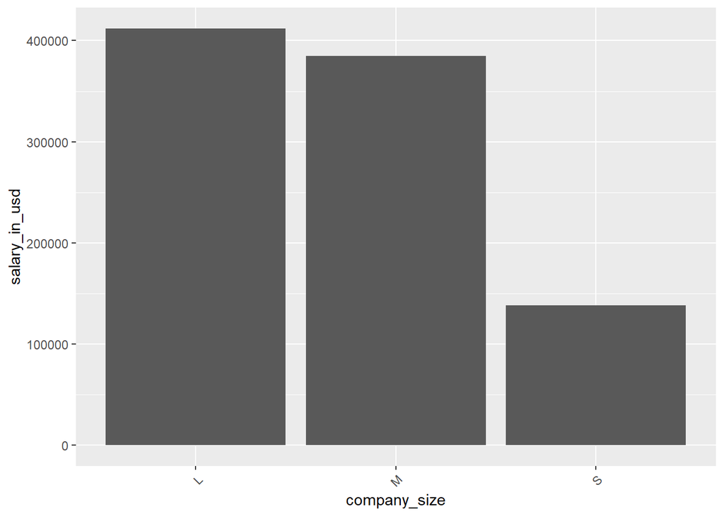

```r
ggplot(data = salaries4) + geom_bar(mapping = aes(x= company_size, y= salary_in_usd),
  stat = "identity", position = "dodge") +theme(axis.text.x = element_text(angle=45, vjust=1, hjust=1))
```

From all of the single and multiple variable graphs above, I combined the information to try and answer my initial question. I used a bar graph to display the company size in relation to salary.

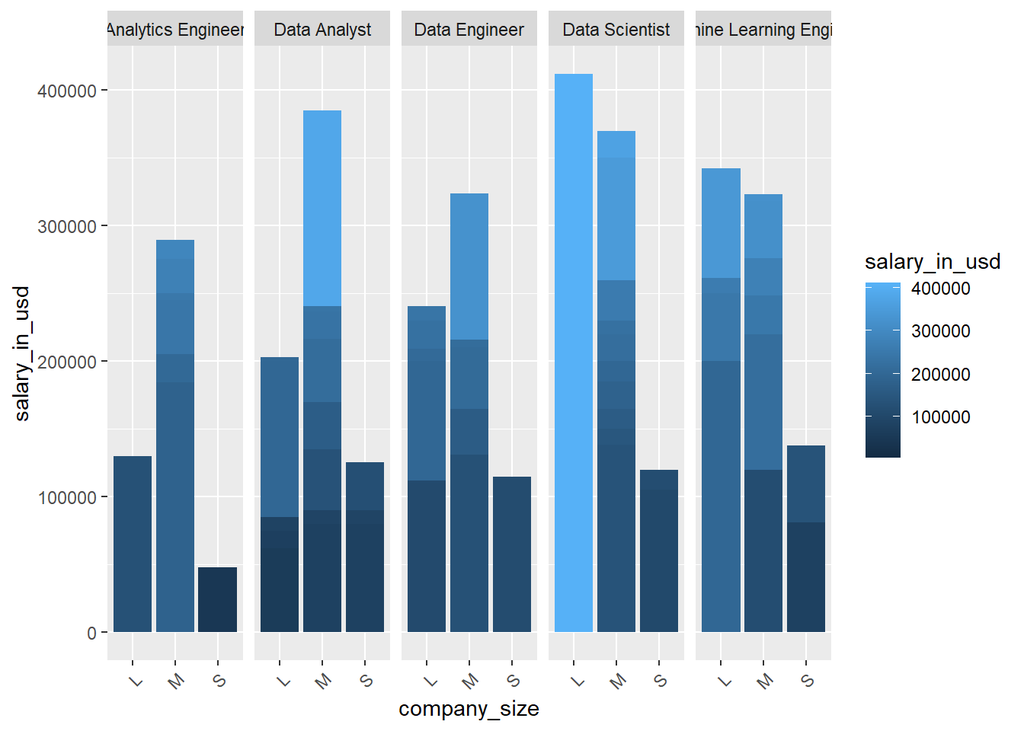

```r
ggplot(data = salaries4) + geom_bar(mapping = aes(x= company_size, y= salary_in_usd, fill=salary_in_usd),
  stat = "identity", position = "dodge") + facet_wrap(~job_title, nrow =1) +theme(axis.text.x = element_text(angle=45, vjust=1, hjust=1))
```

## Step 3: Conclusions

Original question: Do larger companies pay more than medium or smaller companies for data science related jobs?  
Based on the graphs I created, it depends on the job position whether larger companies pay more than medium sized and small sized companies. I started by visualizing each single variable, before, next, looking at the relationship between multiple variables. The salaries vary among the size of companies, based on job title. Specifically, if you look at the data scientist job title, the large company exclusively pays the highest, while the small company has a high frequency of small salaries. However, if you look at the data analyst job title, medium sized companies have higher salaries than the larger companies. If you look across all five positions, small companies have the darkest color, indicating smaller salaries when compared to the medium and large companies. Medium companies have a wide range of smaller and larger salaries.